# MD exercises 7 - Filtering, Grouping, & Summarizing

In these exercises you will choose a subset of rows and summarize a data frame in total and across different levels of other variables using the dplyr package. Note: this file will not compile until you have some of the pieces sorted out. To help you I have commented out most of the file.

As you work, move the start of the commented out part down so that you can work on each new piece and keep the rest commented out.

## Fix incorrect code

Recall the `US_births_2000_2014` data set in the `fivethirtyeight` package used in the 2016 article from FiveThirtyEight.com entitled “Some People Are Too Superstitious To Have A Baby On Friday The 13th” [here](https://fivethirtyeight.com/features/some-people-are-too-superstitious-to-have-a-baby-on-friday-the-13th/).

Instructions:

- Fix the code given to focus on only data corresponding to 2013 births using a function in the `dplyr` package.
- Remember to load all needed packages.
- Assign the name `US_births_2013` to this smaller data frame
- Note that `year` is a numeric variable so you shouldn’t have quotation marks around the value(s) of `year` you specify.

```r
library(dplyr)
library(fivethirtyeight)

US_births_2013 <- US_births_2000_2014 %>%
  filter(year == 2013)

# let's check it out
glimpse(US_births_2013)
```

```
## Observations: 365
## Variables: 6
## $ year          <int> 2013, 2013, 2013, 2013, 2013, 2013, 2013, 2013, ...
## $ month         <int> 1, 1, 1, 1, 1, 1, 1, 1, 1, 1, 1, 1, 1, 1, 1, 1, ...
## $ date_of_month <int> 1, 2, 3, 4, 5, 6, 7, 8, 9, 10, 11, 12, 13, 14, 1...
## $ date          <date> 2013-01-01, 2013-01-02, 2013-01-03, 2013-01-04,...
## $ day_of_week   <ord> Tues, Wed, Thurs, Fri, Sat, Sun, Mon, Tues, Wed,...
## $ births        <int> 7537, 10887, 12616, 12431, 8332, 7271, 11463, 12...
```

## Logical operators and the %in% operator

Suppose we’d like to choose births data for the years 2012 to 2014. The code given shows you many different ways to achieve this. Copy each of them into the Console to check that they return the same data frames.

- The `|` operator can be read as “or”. This should be used when you’d like either of the different operations to be true.
- The `%in%` operator can be used to match conditions provided in a vector using the `c()` function.
- The `!` operator can be read as “not.” It is used to negate a condition.

You can use a comma between arguments to specify you’d like all of the conditions to be met. This is the same as using the “and” operator `&`. Notice that `&` or `,` will not work here to select 2012 to 2014 since there are no values of `year` that are BOTH 2012 **and** 2013 at the same time. This is more useful when you have conditions to meet based on different variables.

Instructions:

- Use the code given as a guide to choose births data for the years 2010, 2011, 2012, and 2014. (This resulting data frame should have 1461 rows.)
- Assign the name `US_births_small` to this data frame. (Note that there are many different ways to solve this. I’m only asking you to produce ONE solution so you should delete the pre-loaded code when you understand how it works and then write your own answer.)

```r
# Check that each of these lines of code results in a data frame with the
# correct number of rows (1096) by running the code in the Console

US_births_small <- US_births_2000_2014 %>%
  filter(year == 2012 | year == 2013 | year == 2014)

glimpse(US_births_small)
```

```
## Observations: 1,096
## Variables: 6
## $ year          <int> 2012, 2012, 2012, 2012, 2012, 2012, 2012, 2012, ...
## $ month         <int> 1, 1, 1, 1, 1, 1, 1, 1, 1, 1, 1, 1, 1, 1, 1, 1, ...
## $ date_of_month <int> 1, 2, 3, 4, 5, 6, 7, 8, 9, 10, 11, 12, 13, 14, 1...
## $ date          <date> 2012-01-01, 2012-01-02, 2012-01-03, 2012-01-04,...
## $ day_of_week   <ord> Sun, Mon, Tues, Wed, Thurs, Fri, Sat, Sun, Mon, ...
## $ births        <int> 6629, 7821, 11324, 12075, 12171, 11920, 7783, 68...
```

## Matching conditions on multiple variables

You can use a comma between arguments to specify you’d like all of the conditions to be met. This is the same as using the “and” operator `&`. Notice that `&` or `,` would not work to select 2012 to 2014 births data since there are no values of `year` that are BOTH 2012 **and** 2013 at the same time for a given row, for example. (Run `US_births_2000_2014 %>% filter(year == 2012, year == 2013, year == 2014)` in the Console to confirm that there are no resulting rows in this data frame.) This is more useful when you have conditions to meet based on different variables.

Instructions - Suppose we are interested in choosing rows for only weekdays (not Saturdays or Sundays) for `day_of_week` in `year` 2013. - Write the code to do so below and give the name `US_births_weekdays_2013` to the resulting data frame. (Note that you may want to run `US_births_2000_2014 %>% distinct(day_of_week)` in the Console to identify the specific values of `day_of_week`.)

```r
US_births_weekdays_2013 <- US_births_2013 %>%
        filter(day_of_week != "Sun" & day_of_week != "Sat")

glimpse(US_births_weekdays_2013)
```

```
## Observations: 261
## Variables: 6
## $ year          <int> 2013, 2013, 2013, 2013, 2013, 2013, 2013, 2013, ...
## $ month         <int> 1, 1, 1, 1, 1, 1, 1, 1, 1, 1, 1, 1, 1, 1, 1, 1, ...
## $ date_of_month <int> 1, 2, 3, 4, 7, 8, 9, 10, 11, 14, 15, 16, 17, 18,...
## $ date          <date> 2013-01-01, 2013-01-02, 2013-01-03, 2013-01-04,...
## $ day_of_week   <ord> Tues, Wed, Thurs, Fri, Mon, Tues, Wed, Thurs, Fr...
## $ births        <int> 7537, 10887, 12616, 12431, 11463, 12040, 11598, ...
```

## Make plot on filtered data

It’s always important to review what you’ve learned in the past and apply it to new problems. Let’s step back into the `ggplot2` environment to plot some variables in the data frame we’ve just created.

Instructions:

- Produce an appropriate plot looking at the pattern of `births` throughout weekdays in 2013 colored by the particular day of the week values. `US_births_weekdays_2013` has been loaded for you so you don’t need to create the data frame again.
- Note that we don’t need to load the `fivethirtyeight` or `dplyr` packages here since we aren’t using functions or data frames inside them specifically with this problem. We do need to load a different package though.

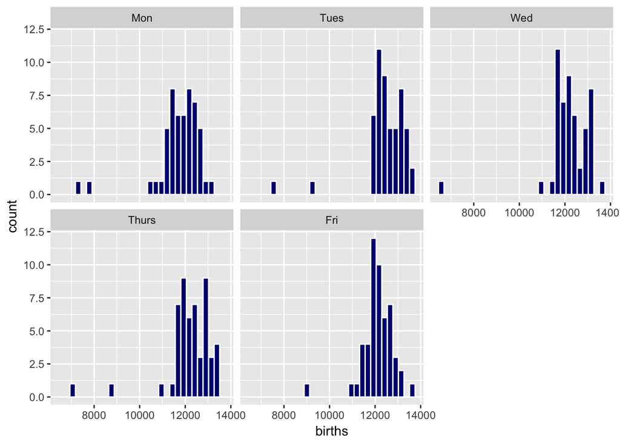

```r
library(ggplot2)

ggplot(data = US_births_weekdays_2013, mapping = aes(x = births, fill = "day_of_week")) +
        geom_histogram(color = "white", fill = "navyblue") +
        facet_wrap(~day_of_week)
```

## Overall mean and median

The plot in the previous exercise has shown there are some outliers in the data for US births on weekdays in 2013. Let’s use the `summarize` function to get an idea for how these outliers may affect the shape of the `births` variable in `US_births_weekdays_2013`.

Instructions:

- Fill in the code below to calculate the `mean` and `median` values for all weekday birth totals in 2013.
- This *aggregated* data frame has been given a name of `birth_summ`.

```r
birth_summ <- US_births_weekdays_2013 %>%
  summarize(mean_births =  mean(births), median_births = median(births))

glimpse(birth_summ)
```

```
## Observations: 1
## Variables: 2
## $ mean_births   <dbl> 12144.66
## $ median_births <int> 12192
```

## Summarizing over another variable

Instead of looking at the overall mean and median across all of 2013 weekdays, we can calculate the mean and median for each of the five different weekdays throughout 2013.

Instructions:

- Fill in the code below to calculate the `mean` and `median` values across the different categories of `day_of_week` for the `US_births_weekdays_2013` data frame.
- Use the same names for the columns as in the `birth_summ` data frame in the previous exercise.
- After writing the code, make sure to output the resulting `birth_day_summ` data frame to check its values.

```r
library(dplyr)
birth_day_summ <- US_births_weekdays_2013 %>%
  group_by(day_of_week) %>%
  summarize( mean_births =  mean(births),
            median_births = median(births))

birth_day_summ # viewing the output
```

```
## # A tibble: 5 × 3
##   day_of_week mean_births median_births
##         <ord>       <dbl>         <dbl>
## 1         Mon    11732.06       11838.5
## 2        Tues    12468.77       12519.0
## 3         Wed    12189.56       12194.0
## 4       Thurs    12193.94       12270.0
## 5         Fri    12132.71       12125.5
```

## Using the geom_col function

With aggregated data like that in the `birth_day_summ` data frame created in the last exercise, we can use the `geom_col` function to produce the barplot in Fig7_1.png (available on populi)

Instructions:

- Write the code to produce this plot. The `birth_day_summ` aggregated data frame has been loaded for you. Yes, that is “goldenrod”.

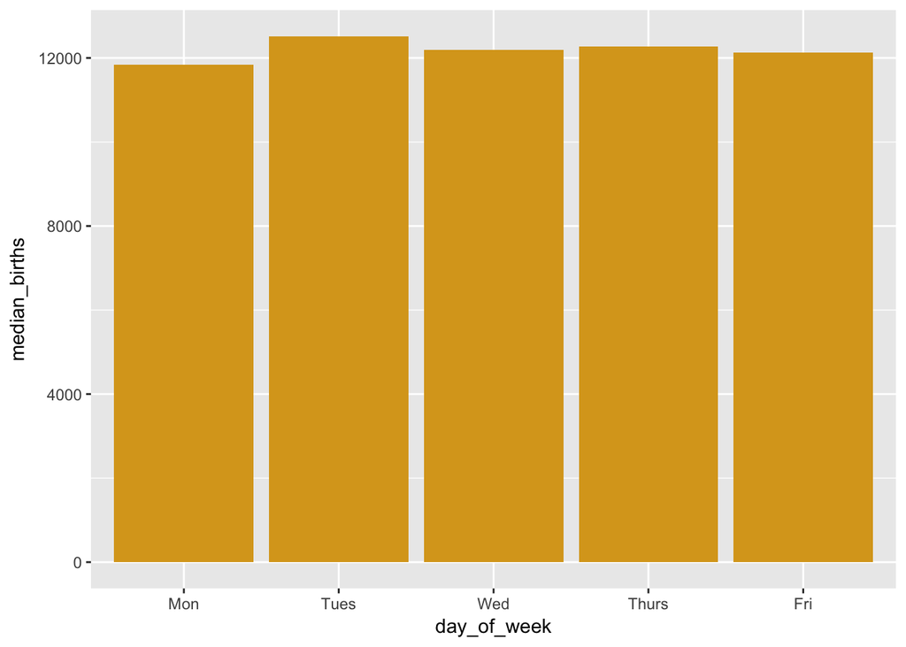

```r
library(ggplot2)

ggplot(data = birth_day_summ, mapping = aes(x = day_of_week , y = median_births)) +
        geom_col(fill = "goldenrod")
```

```r
# I guess: geom_col is similar to geom_bar
```

## Grouping by multiple variables

One great feature of the `group_by` function is its ability to group by more than one variable to show what the aggregated data looks like for combinations of the different variables across the response variable. All that you need to do is add a comma between the different variables in `group_by`. (For example, `group_by(var1, var2)` where `var1` and `var2` are generic variable names. You’ll need to specify the actual variable names for your data frame of interest.)

Another useful tool to calculate the proportion of an occurrence is by invoking the `mean()` function. Suppose we want to count the proportion of “heads” in five tosses of a fair coin. These five tosses result in

`tosses <- c("heads", "tails", "tails", "heads", "heads")`

We can use `mean(tosses == "heads")` to get the resulting answer of 0.6. This works since R converts `tosses == "heads"` into a logical variable. Then when the `mean` function is invoked it sums across the three `TRUE` values that were created and then divides by the five total entries to get the number of 0.6.

Recall the `flying` data frame in the `fivethirtyeight` package you used in the **ggplot2 Review** chapter and its corresponding 2014 article on FiveThirtyEight.com [here](https://fivethirtyeight.com/datalab/airplane-etiquette-recline-seat/).

Instructions:

- You’ve been provided with code to get you started here on using only the complete entries of `flying` and you are asked to continue with the piping using `group_by` and `summarize` to produce the correct aggregated data frame.
- Give a name of `two_group_prop` to this data frame.
- Write the code to determine the proportion of respondents in the survey that responded with `"Very"` when asked if a passenger reclining their seat was rude. You should determine this proportion across the different levels of `age` and `gender` resulting in a data frame of size `8 x 3`. (Note that, unfortunately, only `"Male"` and `"Female"` were given as options on this survey for `gender`.)
- Assign the name `prop_very` to this calculated proportion in this aggregated data frame.
- Make sure to print `two_group_prop` to answer the **THINK ABOUT IT** questions that follow.

```r
library(fivethirtyeight)
library(dplyr)

#two_group_prop <- flying %>%
#                  na.omit() %>%
# let's see what's there in the flying data set
glimpse(flying)
```

```
## Observations: 1,040
## Variables: 27
## $ respondent_id        <dbl> 3436139758, 3434278696, 3434275578, 34342...
## $ gender               <chr> NA, "Male", "Male", "Male", "Male", "Male...
## $ age                  <fctr> NA, 30-44, 30-44, 30-44, 30-44, 30-44, 3...
## $ height               <fctr> NA, 6'3", 5'8", 5'11", 5'7", 5'9", 6'2",...
## $ children_under_18    <lgl> NA, TRUE, FALSE, FALSE, FALSE, TRUE, TRUE...
## $ household_income     <fctr> NA, NA, $100,000 - $149,999, $0 - $24,99...
## $ education            <fctr> NA, Graduate degree, Bachelor degree, Ba...
## $ location             <chr> NA, "Pacific", "Pacific", "Pacific", "Pac...
## $ frequency            <fctr> Once a year or less, Once a year or less...
## $ recline_frequency    <fctr> NA, About half the time, Usually, Always...
## $ recline_obligation   <lgl> NA, TRUE, TRUE, FALSE, FALSE, TRUE, FALSE...
## $ recline_rude         <fctr> NA, Somewhat, No, No, No, No, Somewhat, ...
## $ recline_eliminate    <lgl> NA, FALSE, FALSE, FALSE, FALSE, FALSE, TR...
## $ switch_seats_friends <fctr> NA, No, No, Somewhat, No, Somewhat, Some...
## $ switch_seats_family  <fctr> NA, No, No, No, No, No, No, No, NA, Very...
## $ wake_up_bathroom     <fctr> NA, No, No, No, Somewhat, Somewhat, No, ...
## $ wake_up_walk         <fctr> NA, No, Somewhat, Somewhat, Somewhat, Ve...
## $ baby                 <fctr> NA, No, Somewhat, Somewhat, Somewhat, Ve...
## $ unruly_child         <fctr> NA, No, Very, Very, Very, Very, Somewhat...
## $ two_arm_rests        <chr> NA, "The arm rests should be shared", "Wh...
## $ middle_arm_rest      <chr> NA, "The arm rests should be shared", "Th...
## $ shade                <chr> NA, "Everyone in the row should have some...
## $ unsold_seat          <fctr> NA, No, No, No, No, Somewhat, No, No, No...
## $ talk_stranger        <fctr> NA, No, No, No, No, No, Somewhat, No, No...
## $ get_up               <fctr> NA, Twice, Three times, Three times, Twi...
## $ electronics          <lgl> NA, FALSE, FALSE, FALSE, TRUE, FALSE, FAL...
## $ smoked               <lgl> NA, FALSE, FALSE, FALSE, FALSE, FALSE, FA...
```

```r
two_group_prop <- flying %>%
                        na.omit(flying) %>%
                        group_by(age, gender) %>%
                        # filter(recline_rude == "Very") %>%
                        summarise(prop_very = mean(recline_rude == "Very"))

two_group_prop
```

```
## Source: local data frame [8 x 3]
## Groups: age [?]
##
##      age gender  prop_very
##   <fctr>  <chr>      <dbl>
## 1  18-29 Female 0.11267606
## 2  18-29   Male 0.14035088
## 3  30-44 Female 0.05479452
## 4  30-44   Male 0.07500000
## 5  45-60 Female 0.03529412
## 6  45-60   Male 0.06578947
## 7   > 60 Female 0.13513514
## 8   > 60   Male 0.04545455
```